# 3 Navigating the command line

## 3.1 `pwd`: Find out where we are

To get started, open your terminal, and get yourself oriented by typing your first command and then pressing enter:

```bash
pwd
```

The command `pwd` stands for *print working directory*. It tells you where you currently are in the file system, that is, which folder (directory) your shell is operating on right now. You should see something like this:

```
/Users/YourUserName
```

**TipTip: Finding the Desktop on Different Systems**

Your home directory (i.e. the directory you start in whenever you open the terminal) varies slightly across operating systems. Here’s how to locate yourself and connect to familiar locations like the Desktop:

**macOS**

- Your home directory is `/Users/YourUserName`
- To open the folder you are currently in Finder:`open .`
- Your desktop is at `/Users/YourUserName/Desktop`

**MobaXterm (Windows)**

- Your home directory is `/home/mobaxterm`
- When using the portable version of Mobaxterm this directory is temporary and is deleted when you close MobaXterm. To make it permanent:
  - Go to Settings –> Configuration –> General
  - Under Persistent home directory, choose a folder of your choice
- To open the folder you are currently in the Windows File explorer: `explorer.exe .`
- Your Desktop is usually at: `/mnt/c/Users/YourUserName/Desktop` or `/mnt/c/Users/YourUserName/OneDrive/Desktop` (when using OneDrive)

**WSL2 (Windows)**

- Your home directory is`/home/YourUserName`
- To open the folder you are currently in the Windows File explorer: `explorer.exe .`
- Your Desktop is usually at: `/mnt/c/Users/YourUserName/Desktop` or `/mnt/c/Users/YourUserName/OneDrive/Desktop` (when using OneDrive)

If you want to access the Uva OneDrive folder and/or if your OneDrive folder name includes spaces (like OneDrive - UvA), use quotes around the path:

```bash
cd "/mnt/c/Users/YourUserName/OneDrive - UvA"
```

## 3.2 `ls`: List the contents of a directory

Now that you know where you are, let’s find out what is inside that location, i.e. what files and folders can be found there. The command `ls` (short for *list*) shows the files and folders in your current directory. Type the following and press enter:

```bash
ls
```

You should see something like this (your output will vary depending on what’s in your directory):

[figure not shown]

The colors and formatting depend on your terminal settings, but typically:

- Folders (directories) appear in one color (often green or blue)
- Files appear in another (often white or bold)

If your directory contains many items, the output can quickly become overwhelming. To make sense of it, we can use options and arguments to control how commands behave.

## 3.3 The structure of a command

A command generally has three parts:

- A command name: The program you want to run, i.e. `ls`
- An option (or flag): A way to modify how the command behaves, i.e `-l` (long format)
- An optional argument: The input, i.e. a file or folder

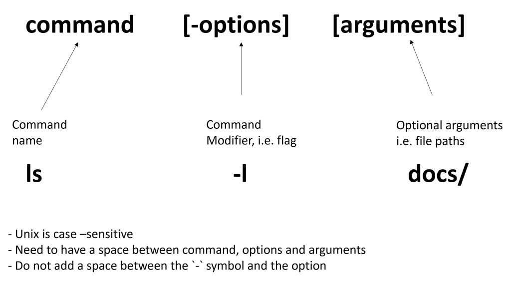

Try the following command in your current directory to “List (`ls`) the contents of the current folder and show details in long format (`-l`)”:

```bash
ls -l
```

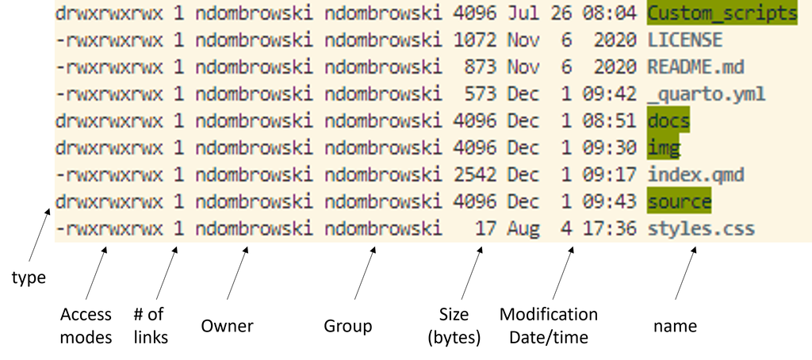

**TipTip: Using ls in practice**

Throughout this tutorial, you’ll notice that we will use `ls` frequently. There is a reason for that:

When working with data, sanity checks are essential, because it is easy to make mistakes, overwrite files, or lose track of where things are. Using simple commands like `ls`, `pwd`, `wc`, or `grep` help you verify what is happening to your files at every step of an analysis workflow.

These habits are not just for beginners, bioinformaticians rely on them constantly.